# Customer Recommendation

```
Thomas van der Molen
S4-AI41
```

- Version History
- Introduction
- Proposal
  - Domain Understanding
    - Real World Examples
    - Question Statement
      - Sub Questions
  - Data Sourcing
  - Analytic Approach
- Provisioning
  - Data Requirements
    - Requirements
  - Data Collection
  - Data Understanding
  - Data Preparation
- Predictions
  - Preprocessing
  - Modelling
  - Evaluation
- Delivery
  - Collecting
  - Documenting
  - Reporting

```python
%%html
<style>
table {float:left}
img {float:left}
</style>
```

## Version History

| Version | Date | Change |
| --- | --- | --- |
| 1.0 | 09-06-2022 | Created document |
| 1.1 | 14-06-2022 | Finished Domain Understanding and Data Sourcing |
| 1.2 | 16-06-2022 | Finished Proposal Phase and started on Data Understanding Visualization |
| 1.3 | 20-06-2022 | Finished Provisioning |
| 1.4 | 21-06-2022 | Finished Predictions |
| 1.5 | 22-06-2022 | Collecting and Documenting |
| 1.6 | 23-06-2022 | Finished Delivery |

## Introduction

During this challenge I will be attempting to use an unsupervised clustering model, in combination with E-commerce customer data to create a recommendation system for an E-commerce website.

All files related to this challenge can be found on my [GitHub](https://github.com/Thomas-Molen/FHICT-S4-AI/tree/main/OpenProgram).

I have decided to do this challenge within the domain of E-commerce, because there are a lot of good examples of artificial inteligence and data analysis being used within this domain. I am also very interested in expanding my knowledge on creating AI models by trying out an unsupervised model technique.

## Proposal

### Domain Understanding

As said in the Introduction I have chosen to do a project in the domain of E-commerce. This industry has become very large over the years, a couple examples of E-commerce stores are:

- Amazon.nl
- Bol.com
- Alibaba.com

A lot of these companies already make use of a form of unsupervised clustering, to recommend users on what to buy, for example on amazon, where on most product pages you can scroll down and see what people that bought this product also looked at or bought.

[figure not shown]

#### Real World Examples

As shown in the Domain Understanding, there are many companies using unsupervised clustering right now to either increase user experience, or as a form of tracking and advertising to users. I have currated a couple more examples of this technique being used in different contexts below.

##### Bol.com

Bol.com is another major online retailer like amazon in the Netherlands, they just like amazon use a similar approach to unsupervised clustering by grouping products together into groups of products that are often viewed together.  
This makes customers more likely to buy multiple products on their website, because often these products are relevant to what is being looked for by the user.

[figure not shown]

##### Steam

[steam](https://store.steampowered.com/) is a DRM and online videogame store, users of this service have a customised store page recommending games based on their activity on the platform such as: looking at, buying, playing, whitelisting games.  
This is a form of unsupervised clustering that groups similar users together to create a recommendation system based on what other users within those groups play.

[figure not shown]

[figure not shown]

#### Netflix

[Netflix](https://www.Netflix.com) is an online streaming service that has a large catalogue of movies, TV-shows and documentaries, to make sure that their users find content that they will enjoy, Netflix also makes use of unsupervised clustering. Netflix uses these AI models to group together their content to use as a recommendation system for their users, if you watched a certain piece of content, other content from that cluster will be recommended to you on your home page.

[figure not shown]

#### Question Statement

For this project I Will be trying to find out: *How to recommend relevant products to users*

I think unsupervised recommendation systems for online websites will stay relevant and important in the future, being an essential part of any webstore or streaming service. There are many different ways of creating recommendations for customers as shown above during the Real World Examples, I will initialy be trying to create a recommendation system by grouping user's purchases. Grouping users based on their purchases will allow for a custom store page to be created, curated to the kind of customer.  
Grouping products on the other hand seems to have diminishing returns, seen as once the user has bought a product of that group there is a lower chance they will need to buy another one.

##### Sub Questions

There are also a couple subquestions that I would like to answer along the way:

- *What kind of data is allowed to be collected by websites*
- *What technical methods are used to create unsupervised recommendation systems*
- *How effective are recommendation systems to keep people on a platform*

##### What kind of data is allowed to be collected by websites

Websites are surprisingly able to collect a lot of data on their users, while the EU has put certain regulations into place to try and limit this, most websites are still able to collect a lot of useful data.

Websites can make use of fingerprinting techinques which can combine data gathered from the user such as IP, browser information, device information and possible tracking cookies to identify users. this [Quora answer](https://www.quora.com/What-data-can-a-website-collect-from-user%E2%80%99s-computer-and-by-which-method-cookies-or-any-other-technique) explains this aswell, creating a bigger list of general information exchanged between clients and websites when just visiting them.

Furthermore, I found this very interested [dataset](http://archive.ics.uci.edu/ml/datasets/Online+Shoppers+Purchasing+Intention+Dataset) on the UCI archives, that shows that websites track the exact actions a user takes on websites, such as time spent on pages, amount of redirects, profit made from user sessions, etc.

##### What technical methods are used to create unsupervised recommendation systems

For this topic I found a very insightful [blog post](https://towardsdatascience.com/recommendation-systems-explained-a42fc60591ed). I will be looking at the three systems explained in the blog post above, these being:

- Collaborative Filtering
- Content Based
- Hybrid Recommendation

  *Collaborative Filtering*  
  This method uses the principle that if people with similar behaviors are more likely to show interests in the same items in the future.  
  For Collaborative Filtering there are two approach: Memory and Model based.

  Memory based is the more prominently discussed one, with this method similar products or people are grouped together and because of their similar behaviors will be expected to like the same things.

  Model based takes the fundamental features from products and bases user's interests on the weight these features might have based on their previous experience.

  *Content Based*  
  This methods uses a user's previously observed interests to suggest items with similar fundamental features. This means that if a user buys a lot of tech products it will be recommended more products from this category, or users who purchase high page count books will be recommended larger books in the future.

  *Hybrid Recommendation*  
  As the name suggests this method allows for the combination of other techniques, most methods such as Collaborative and Content based have their disadvantages (for example content based won't work for new users). Hybrid Recommendation tries to get the best of both worlds by combining methods in either two ways:
  - Parallel
  - Sequential

    *Parallel*  
    Parallel is the simpler of the two, it basically runs the different recommendation methods independently and combines the results.

    *Sequential*  
    Sequential makes use of a large pool of possible items and feeds this list through each method one after the other, continuesly reducing the amount of items from the list untill the final recommendation output is created.

##### How effective are recommendation systems to keep people on a platform

From this [research post](https://www.mckinsey.com/business-functions/growth-marketing-and-sales/our-insights/the-value-of-getting-personalization-right-or-wrong-is-multiplying) which has visualized the general public's opinion on the importance of personalization on websites, gathered from ~2000 people. From this figure it is clearly visible that the large majority of users not only make use of recommendation systems but actually expect it.

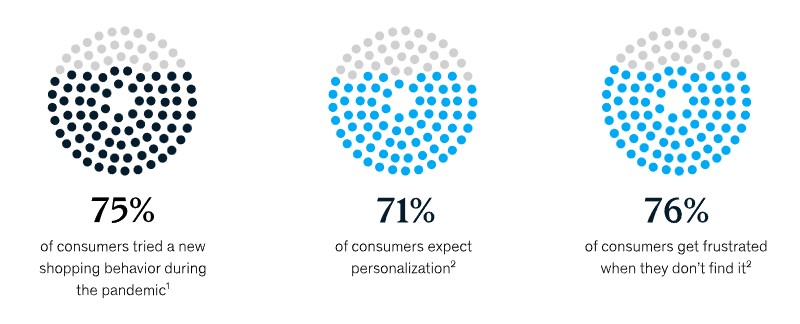

This post also supplied us with another visualization, this one directly looking at the purchase behavior of consumers based on recommended items, taken from ~1000 people. Here it is also clearly visible that not only do people buy the items recommended to them, they have a higher likelyhood of returning to the company because of the better user experience.

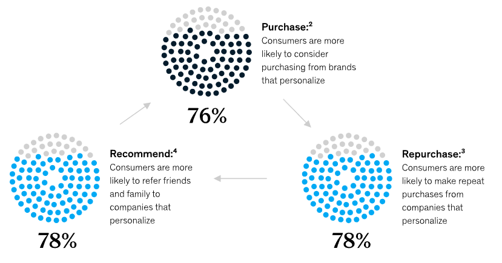

I think this clearly shows that recommendation systems do indeed work, and are prettymuch a necessity for any modern platform.

### Data Sourcing

As discussed during the first sub question, companies are able to gather a lot of the data required to create a recommendation system. However, this data is often very personal and proprietary, for this reason companies often will not give this data out to anyone (if they are even allowed to).

Thankfully a real-world transactions dataset as been supplied to the [UCI repositories](http://archive.ics.uci.edu/ml/datasets/Online+Retail+II), in fact two datasets were supplied during 2019. I will be using the second larger dataset for my challenge, this dataset coverage a two year period from 2009 untill 2011 from a large UK based online retailer.

### Analytic Approach

As explained during the Introduction, I will be trying to make a recommendation system using unsupervised clustering.

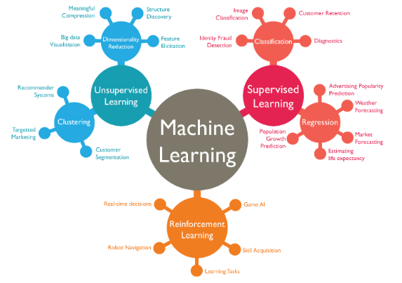

Unsupervised models however, are sort of a blackbox how they work. Because the data used is not labeled in any way it is hard to track exactly what a model did with the input to get it's result. This complicates evaluating the performance of the model.

Luckily it is possible to use methods designed for supervised models here too. For example by splitting the data in test and train data, it can be found if the test products for a user were being recommended to the user before purchase.

Furthermore, evaluation can be done by looking at the amount of products the recommender is recommending to users based on the amount of products available, this can be a good indicator of how aggrasive the model is filtering products.

As for the target variable. Because the data is unlabeled, there isn't a direct feature to be used as the target variable. However, it can be considered that the target is the products the model will be recommending.

## Provisioning

As stated during the Data Sourcing, it is very hard to find customer data, with the best source that I could find being on the [UCI repositories](http://archive.ics.uci.edu/ml/datasets/Online+Retail+II). Because the data is not directly supplied by the company the data originated from, there will possibily be information or nuances of the data missing.  
The lack of direct contact with the original data holders will mean that more care will have to be taken when analyzing the data, as to not create bad conclusions.

### Data Requirements

The dataset being used (supplied by UCI) contains ~1.000.000 records, these records being purchases of a products that could be part of a larger invoice. The records are split up in two tables; 2009-2010 and 2010-2011, as seen from these year counts there seems to be overlap between the periods, this means it will be important to make sure no duplicate entries exist.

As for the features, thankfully on the UCI page the different features are referenced with short explenations of them, this combined with the relative straightforward naming of the features, should not create a problem in the future.

The features I will be looking for, are a form of: customer identifier, product identifier and rating/quantity. I will be wanting indentifiers for the customer and product as to link them together, this will allow me to find the products that users are purchasing and grouping users with similar products together.  
Lastly I will also want a form to quantify how much a customer wants an item compared to other items, the best statistic for this would be user ratings for the products, but other identifiers such as quantity purchased can also be used.

The dataset does reference that there are missing values in the dataset, this will also have to be looked at during data understanding.

My main focus will be to make sure the dataset does not contain any missing data for the product bought and purchase information such as invoice no. and user ID. Furthermore, I will be making sure that the dataset does not contain any duplicate entries.

### Data Collection

The dataset supplied Dr. Daqing Chen on UCI, was originally used for a case study on customer segmentation using data mining, this case study is very close to the use case I will be using the dataset for.

Sadly the UK based company the data originates from has been kept confidential, so the only way to inquery about the dataset, or possibily get more data would be through Dr. Daqing Chen.

Dr. Daqing Chen, had donated an earlier dataset in 2015, this dataset being only the 2010-2011 table from the larger dataset uploaded to UCI a in 2019.

### Data Understanding

```python
import pandas as pd
import numpy as np
import seaborn as sns
import matplotlib.pyplot as plt

print('numpy version:', np.__version__)
print('pandas version:', pd.__version__)
print('seaborn version:', sns.__version__)
```

```
numpy version: 1.20.3
pandas version: 1.3.4
seaborn version: 0.11.2
```

```python
df = pd.read_excel('Datasets/invoices.xlsx', sheet_name=[0,1])
```

The dataset supplied is in excel format and split into two tables. For this reason the seperate data sheets will be loaded into a dict where the sheet wanted can be filtered.

```python
df[0].info()
df[0].head()
```

```
<class 'pandas.core.frame.DataFrame'>
RangeIndex: 525461 entries, 0 to 525460
Data columns (total 8 columns):
 #   Column       Non-Null Count   Dtype
---  ------       --------------   -----
 0   Invoice      525461 non-null  object
 1   StockCode    525461 non-null  object
 2   Description  522533 non-null  object
 3   Quantity     525461 non-null  int64
 4   InvoiceDate  525461 non-null  datetime64[ns]
 5   Price        525461 non-null  float64
 6   Customer ID  417534 non-null  float64
 7   Country      525461 non-null  object
dtypes: datetime64[ns](1), float64(2), int64(1), object(4)
memory usage: 32.1+ MB
```

|  | Invoice | StockCode | Description | Quantity | InvoiceDate | Price | Customer ID | Country |
| --- | --- | --- | --- | --- | --- | --- | --- | --- |
| 0 | 489434 | 85048 | 15CM CHRISTMAS GLASS BALL 20 LIGHTS | 12 | 2009-12-01 07:45:00 | 6.95 | 13085.0 | United Kingdom |
| 1 | 489434 | 79323P | PINK CHERRY LIGHTS | 12 | 2009-12-01 07:45:00 | 6.75 | 13085.0 | United Kingdom |
| 2 | 489434 | 79323W | WHITE CHERRY LIGHTS | 12 | 2009-12-01 07:45:00 | 6.75 | 13085.0 | United Kingdom |
| 3 | 489434 | 22041 | RECORD FRAME 7" SINGLE SIZE | 48 | 2009-12-01 07:45:00 | 2.10 | 13085.0 | United Kingdom |
| 4 | 489434 | 21232 | STRAWBERRY CERAMIC TRINKET BOX | 24 | 2009-12-01 07:45:00 | 1.25 | 13085.0 | United Kingdom |

The dataset seems to have loaded properly, also using the correct column names and parsing the datetime correctly.

| Column | Information |
| --- | --- |
| Invoice | Holds the ID of the invoice that the product purchase is a part of |
| StockCode | Is the ID of purchase |
| Description | Description of the product being purchased |
| Quantity | Quantity of the product being purchased |
| InvoiceDate | a minute precise datetime of when the transaction was created |
| Price | sale price of a single unit in GBP(£) |
| Customer ID | ID of the customer |
| Country | Country of the customer |

In the table above it can be seen what each column contains, based on information supplied on UCI.

StockCode together with Customer ID will be the most useful columns as these can connect a customer to a product he bought, this creating the target for the recommendation.

The Invoice column will be usefull to keep track of which purchases were made together.

Description column will not be of much use, seen as this column only describes the item further, which is not necessary with the StockCode. Description could however be used for creating extra product features such as color of the product.

Quantity is a good indicator of how much interest a user has in a product.

InvoiceData, is not very important with the only aspect that could be considered is seasonal products, however most recommendation systems do not take date into account.

Price is not of great importance for possible recommendation, only being useful to priorities the largest profits or to target big spenders.

Country could be a useful indicator is people from the same countries buy the same products.

```python
df[0].describe()
```

|  | Quantity | Price | Customer ID |
| --- | --- | --- | --- |
| count | 525461.000000 | 525461.000000 | 417534.000000 |
| mean | 10.337667 | 4.688834 | 15360.645478 |
| std | 107.424110 | 146.126914 | 1680.811316 |
| min | -9600.000000 | -53594.360000 | 12346.000000 |
| 25% | 1.000000 | 1.250000 | 13983.000000 |
| 50% | 3.000000 | 2.100000 | 15311.000000 |
| 75% | 10.000000 | 4.210000 | 16799.000000 |
| max | 19152.000000 | 25111.090000 | 18287.000000 |

```python
df[1].describe()
```

|  | Quantity | Price | Customer ID |
| --- | --- | --- | --- |
| count | 541910.000000 | 541910.000000 | 406830.000000 |
| mean | 9.552234 | 4.611138 | 15287.684160 |
| std | 218.080957 | 96.759765 | 1713.603074 |
| min | -80995.000000 | -11062.060000 | 12346.000000 |
| 25% | 1.000000 | 1.250000 | 13953.000000 |
| 50% | 3.000000 | 2.080000 | 15152.000000 |
| 75% | 10.000000 | 4.130000 | 16791.000000 |
| max | 80995.000000 | 38970.000000 | 18287.000000 |

```python
df[0].sort_values('Price')
```

|  | Invoice | StockCode | Description | Quantity | InvoiceDate | Price | Customer ID | Country |
| --- | --- | --- | --- | --- | --- | --- | --- | --- |
| 179403 | A506401 | B | Adjust bad debt | 1 | 2010-04-29 13:36:00 | -53594.36 | NaN | United Kingdom |
| 276274 | A516228 | B | Adjust bad debt | 1 | 2010-07-19 11:24:00 | -44031.79 | NaN | United Kingdom |
| 403472 | A528059 | B | Adjust bad debt | 1 | 2010-10-20 12:04:00 | -38925.87 | NaN | United Kingdom |
| 264267 | 514947 | 84509F | NaN | -23 | 2010-07-07 11:45:00 | 0.00 | NaN | United Kingdom |
| 221076 | 510876 | 90025B | NaN | -42 | 2010-06-04 09:58:00 | 0.00 | NaN | United Kingdom |
| ... | ... | ... | ... | ... | ... | ... | ... | ... |
| 519294 | C537651 | AMAZONFEE | AMAZON FEE | -1 | 2010-12-07 15:49:00 | 13541.33 | NaN | United Kingdom |
| 517955 | 537632 | AMAZONFEE | AMAZON FEE | 1 | 2010-12-07 15:08:00 | 13541.33 | NaN | United Kingdom |
| 320581 | C520667 | BANK CHARGES | Bank Charges | -1 | 2010-08-27 13:42:00 | 18910.69 | NaN | United Kingdom |
| 241827 | 512771 | M | Manual | 1 | 2010-06-17 16:53:00 | 25111.09 | NaN | United Kingdom |
| 241824 | C512770 | M | Manual | -1 | 2010-06-17 16:52:00 | 25111.09 | 17399.0 | United Kingdom |

525461 rows × 8 columns

When looking at the columns multiple things are noticeable, firstly quantity and price can have a negative number. These records are either corrupted or where returns/chargebacks, which should be removed, and if possible also remove the record of the item returned, seen as the user did not end up wanting the product and returned it.

Furthermore, the StockCode and Decription are not necessarily automated, as none standard code and descriptions are being used by some transactions, these will cause problems as the ones shown above aren't actual available products that should be recommended.

```python
print(df[0].isnull().sum(), '\n')

print(df[1].isnull().sum())
```

```
Invoice             0
StockCode           0
Description      2928
Quantity            0
InvoiceDate         0
Price               0
Customer ID    107927
Country             0
dtype: int64

Invoice             0
StockCode           0
Description      1454
Quantity            0
InvoiceDate         0
Price               0
Customer ID    135080
Country             0
dtype: int64
```

As seen there are missing values in the columns Description and Customer ID, this means that ~230.000/~1.000.000 sales has no customer attached to them, this will cause problems for recommendation systems that make use of creating user profiles or grouping users.

```python
df[0][df[0]['Customer ID'].isnull()].head(20)
```

|  | Invoice | StockCode | Description | Quantity | InvoiceDate | Price | Customer ID | Country |
| --- | --- | --- | --- | --- | --- | --- | --- | --- |
| 263 | 489464 | 21733 | 85123a mixed | -96 | 2009-12-01 10:52:00 | 0.00 | NaN | United Kingdom |
| 283 | 489463 | 71477 | short | -240 | 2009-12-01 10:52:00 | 0.00 | NaN | United Kingdom |
| 284 | 489467 | 85123A | 21733 mixed | -192 | 2009-12-01 10:53:00 | 0.00 | NaN | United Kingdom |
| 470 | 489521 | 21646 | NaN | -50 | 2009-12-01 11:44:00 | 0.00 | NaN | United Kingdom |
| 577 | 489525 | 85226C | BLUE PULL BACK RACING CAR | 1 | 2009-12-01 11:49:00 | 0.55 | NaN | United Kingdom |
| 578 | 489525 | 85227 | SET/6 3D KIT CARDS FOR KIDS | 1 | 2009-12-01 11:49:00 | 0.85 | NaN | United Kingdom |
| 1055 | 489548 | 22271 | FELTCRAFT DOLL ROSIE | 1 | 2009-12-01 12:32:00 | 2.95 | NaN | United Kingdom |
| 1056 | 489548 | 22254 | FELT TOADSTOOL LARGE | 12 | 2009-12-01 12:32:00 | 1.25 | NaN | United Kingdom |
| 1057 | 489548 | 22273 | FELTCRAFT DOLL MOLLY | 3 | 2009-12-01 12:32:00 | 2.95 | NaN | United Kingdom |
| 1058 | 489548 | 22195 | LARGE HEART MEASURING SPOONS | 1 | 2009-12-01 12:32:00 | 1.65 | NaN | United Kingdom |
| 1059 | 489548 | 22131 | FOOD CONTAINER SET 3 LOVE HEART | 2 | 2009-12-01 12:32:00 | 1.95 | NaN | United Kingdom |
| 1060 | 489548 | 22079 | RIBBON REEL HEARTS DESIGN | 10 | 2009-12-01 12:32:00 | 1.65 | NaN | United Kingdom |
| 1061 | 489548 | 22138 | BAKING SET 9 PIECE RETROSPOT | 3 | 2009-12-01 12:32:00 | 4.95 | NaN | United Kingdom |
| 1062 | 489548 | 22147 | FELTCRAFT BUTTERFLY HEARTS | 2 | 2009-12-01 12:32:00 | 1.45 | NaN | United Kingdom |
| 1063 | 489548 | 22142 | CHRISTMAS CRAFT WHITE FAIRY | 2 | 2009-12-01 12:32:00 | 1.45 | NaN | United Kingdom |
| 1064 | 489548 | 22150 | 3 STRIPEY MICE FELTCRAFT | 2 | 2009-12-01 12:32:00 | 1.95 | NaN | United Kingdom |
| 1065 | 489548 | 20804 | GLASS CHICKEN BUTTER DISH | 1 | 2009-12-01 12:32:00 | 1.65 | NaN | United Kingdom |
| 1066 | 489548 | 22196 | SMALL HEART MEASURING SPOONS | 8 | 2009-12-01 12:32:00 | 0.85 | NaN | United Kingdom |
| 1067 | 489548 | 22086 | PAPER CHAIN KIT 50'S CHRISTMAS | 3 | 2009-12-01 12:32:00 | 2.95 | NaN | United Kingdom |
| 1068 | 489548 | 21115 | ROSE CARAVAN DOORSTOP | 1 | 2009-12-01 12:32:00 | 6.75 | NaN | United Kingdom |

First thing seen is the description for records 263 and 284, reference eachother's products, this gives me the idea that StockCode is not as straightforward as it might seem, seen as products can be a mix of StockCodes, and only one of the StockCode is being referenced, instead of two records showing both are bought.

Furthermore, the CustomerID seems to be empty for seemingly valid purchases, such as invoice 489548, seen as the company this dataset is obtained from is an online only retailer, this could not be a customer making a purchase on location. Perhaps, this is a side-effect of a user deleting his account and the reference to his account being removed, or it being a corrupted invoice.

```python
for i in range(2):
    print(f"({i}) invoices with missing customerID:", len(df[i][df[i]['Customer ID'].isnull()]['Invoice'].unique()))
```

```
(0) invoices with missing customerID: 5229
(1) invoices with missing customerID: 3710
```

```python
df[0][(df[0]['Customer ID'].isnull())]
```

|  | Invoice | StockCode | Description | Quantity | InvoiceDate | Price | Customer ID | Country |
| --- | --- | --- | --- | --- | --- | --- | --- | --- |
| 263 | 489464 | 21733 | 85123a mixed | -96 | 2009-12-01 10:52:00 | 0.00 | NaN | United Kingdom |
| 283 | 489463 | 71477 | short | -240 | 2009-12-01 10:52:00 | 0.00 | NaN | United Kingdom |
| 284 | 489467 | 85123A | 21733 mixed | -192 | 2009-12-01 10:53:00 | 0.00 | NaN | United Kingdom |
| 470 | 489521 | 21646 | NaN | -50 | 2009-12-01 11:44:00 | 0.00 | NaN | United Kingdom |
| 577 | 489525 | 85226C | BLUE PULL BACK RACING CAR | 1 | 2009-12-01 11:49:00 | 0.55 | NaN | United Kingdom |
| ... | ... | ... | ... | ... | ... | ... | ... | ... |
| 525231 | 538159 | 21324 | NaN | -18 | 2010-12-09 17:17:00 | 0.00 | NaN | United Kingdom |
| 525232 | 538158 | 20892 | NaN | -32 | 2010-12-09 17:17:00 | 0.00 | NaN | United Kingdom |
| 525233 | 538160 | 20956 | NaN | 288 | 2010-12-09 17:18:00 | 0.00 | NaN | United Kingdom |
| 525234 | 538161 | 46000S | Dotcom sales | -100 | 2010-12-09 17:25:00 | 0.00 | NaN | United Kingdom |
| 525235 | 538162 | 46000M | Dotcom sales | -100 | 2010-12-09 17:25:00 | 0.00 | NaN | United Kingdom |

107927 rows × 8 columns

There are ~9000 different invoices with a missing customerID, this means that it did not happen just once but is something that has happened repeatedly, it also happens across the whole period of the data, so it was not a bug or issue with a technical system. This makes me fairly certain in thinking that the Customer ID was removed afterwards, possibly on request of the customer or for a privacy reason.

```python
for invoice in df[0].head(300)['Invoice'].unique():
    if((not df[0][df[0]['Invoice'] == invoice]['StockCode'].is_unique) & (not df[0][df[0]['Invoice'] == invoice]['Description'].is_unique)):
        print(f"Invoice: {invoice} contains same product multiple times")
```

```
Invoice: 489488 contains same product multiple times
```

```python
df[0][df[0]['Invoice'] == 489488]
```

|  | Invoice | StockCode | Description | Quantity | InvoiceDate | Price | Customer ID | Country |
| --- | --- | --- | --- | --- | --- | --- | --- | --- |
| 286 | 489488 | 84031B | CHARLIE LOLA BLUE HOT WATER BOTTLE | 1 | 2009-12-01 10:59:00 | 4.65 | 17238.0 | United Kingdom |
| 287 | 489488 | 84032A | CHARLIE+LOLA PINK HOT WATER BOTTLE | 1 | 2009-12-01 10:59:00 | 2.95 | 17238.0 | United Kingdom |
| 288 | 489488 | 84032B | CHARLIE + LOLA RED HOT WATER BOTTLE | 1 | 2009-12-01 10:59:00 | 2.95 | 17238.0 | United Kingdom |
| 289 | 489488 | 22125 | UNION JACK HOT WATER BOTTLE | 2 | 2009-12-01 10:59:00 | 5.95 | 17238.0 | United Kingdom |
| 290 | 489488 | 21482 | MUSHROOM BLUE HOT WATER BOTTLE | 2 | 2009-12-01 10:59:00 | 2.95 | 17238.0 | United Kingdom |
| 291 | 489488 | 21484 | CHICK GREY HOT WATER BOTTLE | 3 | 2009-12-01 10:59:00 | 3.45 | 17238.0 | United Kingdom |
| 292 | 489488 | 20967 | GREY FLORAL FELTCRAFT SHOULDER BAG | 1 | 2009-12-01 10:59:00 | 3.75 | 17238.0 | United Kingdom |
| 293 | 489488 | 20970 | PINK FLORAL FELTCRAFT SHOULDER BAG | 2 | 2009-12-01 10:59:00 | 3.75 | 17238.0 | United Kingdom |
| 294 | 489488 | 21100 | CHARLIE AND LOLA CHARLOTTE BAG | 2 | 2009-12-01 10:59:00 | 1.65 | 17238.0 | United Kingdom |
| 295 | 489488 | 84582 | PINK CROCHET CAT WITH SCARF | 2 | 2009-12-01 10:59:00 | 4.25 | 17238.0 | United Kingdom |
| 296 | 489488 | 20972 | PINK CREAM FELT CRAFT TRINKET BOX | 3 | 2009-12-01 10:59:00 | 1.25 | 17238.0 | United Kingdom |
| 297 | 489488 | 20971 | PINK BLUE FELT CRAFT TRINKET BOX | 1 | 2009-12-01 10:59:00 | 1.25 | 17238.0 | United Kingdom |
| 298 | 489488 | 84327A | PINK JUMPER LARRY THE LAMB | 2 | 2009-12-01 10:59:00 | 2.10 | 17238.0 | United Kingdom |
| 299 | 489488 | 22125 | UNION JACK HOT WATER BOTTLE | 1 | 2009-12-01 10:59:00 | 5.95 | 17238.0 | United Kingdom |
| 300 | 489488 | 21490 | SET OF THREE 50'S GIFT WRAPS | 3 | 2009-12-01 10:59:00 | 1.95 | 17238.0 | United Kingdom |
| 301 | 489488 | 21063 | PARTY INVITES JAZZ HEARTS | 4 | 2009-12-01 10:59:00 | 0.85 | 17238.0 | United Kingdom |
| 302 | 489488 | 21058 | PARTY INVITES WOODLAND | 3 | 2009-12-01 10:59:00 | 0.85 | 17238.0 | United Kingdom |
| 303 | 489488 | 22086 | PAPER CHAIN KIT 50'S CHRISTMAS | 5 | 2009-12-01 10:59:00 | 2.95 | 17238.0 | United Kingdom |
| 304 | 489488 | 84997D | PINK 3 PIECE MINI DOTS CUTLERY SET | 4 | 2009-12-01 10:59:00 | 3.75 | 17238.0 | United Kingdom |
| 305 | 489488 | 84997C | BLUE 3 PIECE MINI DOTS CUTLERY SET | 4 | 2009-12-01 10:59:00 | 3.75 | 17238.0 | United Kingdom |
| 306 | 489488 | 22301 | COFFEE MUG CAT + BIRD DESIGN | 2 | 2009-12-01 10:59:00 | 2.55 | 17238.0 | United Kingdom |
| 307 | 489488 | 22300 | COFFEE MUG DOG + BALL DESIGN | 3 | 2009-12-01 10:59:00 | 2.55 | 17238.0 | United Kingdom |
| 308 | 489488 | 21493 | VINTAGE DESIGN GIFT TAGS | 6 | 2009-12-01 10:59:00 | 0.85 | 17238.0 | United Kingdom |
| 309 | 489488 | 21231 | SWEETHEART CERAMIC TRINKET BOX | 4 | 2009-12-01 10:59:00 | 1.25 | 17238.0 | United Kingdom |
| 310 | 489488 | 20870 | OPULENT VELVET CANDLE IN BOX | 6 | 2009-12-01 10:59:00 | 2.10 | 17238.0 | United Kingdom |
| 311 | 489488 | 90121B | VINTAGE ROSE BEAD BRACELET BLUE | 4 | 2009-12-01 10:59:00 | 4.25 | 17238.0 | United Kingdom |
| 312 | 489488 | 90175A | WHITE GLASS CHUNKY CHARM BRACELET | 2 | 2009-12-01 10:59:00 | 8.95 | 17238.0 | United Kingdom |
| 313 | 489488 | 90195B | BLACK GEMSTONE BRACELET | 2 | 2009-12-01 10:59:00 | 8.95 | 17238.0 | United Kingdom |
| 314 | 489488 | 90062 | CARNIVAL BRACELET | 2 | 2009-12-01 10:59:00 | 12.75 | 17238.0 | United Kingdom |
| 315 | 489488 | 21930 | JUMBO STORAGE BAG SKULLS | 2 | 2009-12-01 10:59:00 | 1.95 | 17238.0 | United Kingdom |

Somehow the same invoice can contain the same product being bought multiple times, why this isn't just one entry with the quantities added up I do not understand, when looking at record 289/299 the products are completely identical

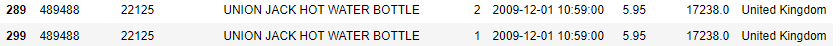

```python
df_merge = df[1].merge(df[0].drop_duplicates(), on=df[0].columns.tolist(), how='left', indicator=True)
```

Checking for overlap between data sheets

```python
df_merge[df_merge['_merge'] == 'both'].head(1)
```

|  | Invoice | StockCode | Description | Quantity | InvoiceDate | Price | Customer ID | Country | _merge |
| --- | --- | --- | --- | --- | --- | --- | --- | --- | --- |
| 0 | 536365 | 85123A | WHITE HANGING HEART T-LIGHT HOLDER | 6 | 2010-12-01 08:26:00 | 2.55 | 17850.0 | United Kingdom | both |

```python
df[0][(df[0]['Invoice'] == 536365)]
```

|  | Invoice | StockCode | Description | Quantity | InvoiceDate | Price | Customer ID | Country |
| --- | --- | --- | --- | --- | --- | --- | --- | --- |
| 502938 | 536365 | 85123A | WHITE HANGING HEART T-LIGHT HOLDER | 6 | 2010-12-01 08:26:00 | 2.55 | 17850.0 | United Kingdom |
| 502939 | 536365 | 71053 | WHITE METAL LANTERN | 6 | 2010-12-01 08:26:00 | 3.39 | 17850.0 | United Kingdom |
| 502940 | 536365 | 84406B | CREAM CUPID HEARTS COAT HANGER | 8 | 2010-12-01 08:26:00 | 2.75 | 17850.0 | United Kingdom |
| 502941 | 536365 | 84029G | KNITTED UNION FLAG HOT WATER BOTTLE | 6 | 2010-12-01 08:26:00 | 3.39 | 17850.0 | United Kingdom |
| 502942 | 536365 | 84029E | RED WOOLLY HOTTIE WHITE HEART. | 6 | 2010-12-01 08:26:00 | 3.39 | 17850.0 | United Kingdom |
| 502943 | 536365 | 22752 | SET 7 BABUSHKA NESTING BOXES | 2 | 2010-12-01 08:26:00 | 7.65 | 17850.0 | United Kingdom |
| 502944 | 536365 | 21730 | GLASS STAR FROSTED T-LIGHT HOLDER | 6 | 2010-12-01 08:26:00 | 4.25 | 17850.0 | United Kingdom |

```python
df[1][(df[1]['Invoice'] == 536365)]
```

|  | Invoice | StockCode | Description | Quantity | InvoiceDate | Price | Customer ID | Country |
| --- | --- | --- | --- | --- | --- | --- | --- | --- |
| 0 | 536365 | 85123A | WHITE HANGING HEART T-LIGHT HOLDER | 6 | 2010-12-01 08:26:00 | 2.55 | 17850.0 | United Kingdom |
| 1 | 536365 | 71053 | WHITE METAL LANTERN | 6 | 2010-12-01 08:26:00 | 3.39 | 17850.0 | United Kingdom |
| 2 | 536365 | 84406B | CREAM CUPID HEARTS COAT HANGER | 8 | 2010-12-01 08:26:00 | 2.75 | 17850.0 | United Kingdom |
| 3 | 536365 | 84029G | KNITTED UNION FLAG HOT WATER BOTTLE | 6 | 2010-12-01 08:26:00 | 3.39 | 17850.0 | United Kingdom |
| 4 | 536365 | 84029E | RED WOOLLY HOTTIE WHITE HEART. | 6 | 2010-12-01 08:26:00 | 3.39 | 17850.0 | United Kingdom |
| 5 | 536365 | 22752 | SET 7 BABUSHKA NESTING BOXES | 2 | 2010-12-01 08:26:00 | 7.65 | 17850.0 | United Kingdom |
| 6 | 536365 | 21730 | GLASS STAR FROSTED T-LIGHT HOLDER | 6 | 2010-12-01 08:26:00 | 4.25 | 17850.0 | United Kingdom |

Above I have merged the two different sheets of the dataset and checked if there is any overlap between the sheets, as mentioned during the Data Requirements I thought there would be overlap because the odd overlapping date ranges. My suspicions as seen from above seem to be true, this means that these duplicates will have to be removed when merging datasets.

##### Visualization

```python
import matplotlib.pyplot as plt
import seaborn as sns
```

Firstly I will be merging the two dataframes while avoiding the overlapping data, this will give a full view of all records available in both sheets for easier visualization

```python
df_merge = df[1].merge(df[0].drop_duplicates(), on=df[0].columns.tolist(), how='left', indicator=True)
```

```python
df_merge[df_merge['_merge'] == 'left_only']
```

|  | Invoice | StockCode | Description | Quantity | InvoiceDate | Price | Customer ID | Country | _merge |
| --- | --- | --- | --- | --- | --- | --- | --- | --- | --- |
| 22523 | 538172 | 21562 | HAWAIIAN GRASS SKIRT | 12 | 2010-12-10 09:33:00 | 1.25 | 15805.0 | United Kingdom | left_only |
| 22524 | 538172 | 79321 | CHILLI LIGHTS | 8 | 2010-12-10 09:33:00 | 4.95 | 15805.0 | United Kingdom | left_only |
| 22525 | 538172 | 22041 | RECORD FRAME 7" SINGLE SIZE | 12 | 2010-12-10 09:33:00 | 2.55 | 15805.0 | United Kingdom | left_only |
| 22526 | 538172 | 84558A | 3D DOG PICTURE PLAYING CARDS | 12 | 2010-12-10 09:33:00 | 2.95 | 15805.0 | United Kingdom | left_only |
| 22527 | 538172 | 22952 | 60 CAKE CASES VINTAGE CHRISTMAS | 24 | 2010-12-10 09:33:00 | 0.55 | 15805.0 | United Kingdom | left_only |
| ... | ... | ... | ... | ... | ... | ... | ... | ... | ... |
| 541905 | 581587 | 22899 | CHILDREN'S APRON DOLLY GIRL | 6 | 2011-12-09 12:50:00 | 2.10 | 12680.0 | France | left_only |
| 541906 | 581587 | 23254 | CHILDRENS CUTLERY DOLLY GIRL | 4 | 2011-12-09 12:50:00 | 4.15 | 12680.0 | France | left_only |
| 541907 | 581587 | 23255 | CHILDRENS CUTLERY CIRCUS PARADE | 4 | 2011-12-09 12:50:00 | 4.15 | 12680.0 | France | left_only |
| 541908 | 581587 | 22138 | BAKING SET 9 PIECE RETROSPOT | 3 | 2011-12-09 12:50:00 | 4.95 | 12680.0 | France | left_only |
| 541909 | 581587 | POST | POSTAGE | 1 | 2011-12-09 12:50:00 | 18.00 | 12680.0 | France | left_only |

519387 rows × 9 columns

```python
df_merge = df[1].merge(df[0].drop_duplicates(), on=df[0].columns.tolist(), how='left', indicator=True)
bdf = df[0].append(df_merge[df_merge['_merge'] == 'left_only'])
del bdf['_merge']
```

Setting the datatypes for easier visualization

```python
bdf['Invoice'] = bdf['Invoice'].astype('category')
bdf['StockCode'] = bdf['StockCode'].astype('category')
bdf['Country'] = bdf['Country'].astype('category')
bdf.info()
```

```
<class 'pandas.core.frame.DataFrame'>
Int64Index: 1044848 entries, 0 to 541909
Data columns (total 8 columns):
 #   Column       Non-Null Count    Dtype
---  ------       --------------    -----
 0   Invoice      1044848 non-null  category
 1   StockCode    1044848 non-null  category
 2   Description  1040573 non-null  object
 3   Quantity     1044848 non-null  int64
 4   InvoiceDate  1044848 non-null  datetime64[ns]
 5   Price        1044848 non-null  float64
 6   Customer ID  809561 non-null   float64
 7   Country      1044848 non-null  category
dtypes: category(3), datetime64[ns](1), float64(2), int64(1), object(1)
memory usage: 57.4+ MB
```

As expected, the full dataset contains ~1.000.000 records.

```python
top_products = bdf.groupby(['StockCode']).size().sort_values(ascending=False)

stock_total = len(bdf['StockCode'].unique())
total_count = top_products.sum()

print(f"Top 10/{stock_total}: {top_products[:10].sum()}/{total_count} ({(top_products[:10].sum()/total_count)*100:.2f}%)")
print(f"Top 50/{stock_total}: {top_products[:50].sum()}/{total_count} ({(top_products[:50].sum()/total_count)*100:.2f}%)")
```

```
Top 10/5305: 33995/1044848 (3.25%)
Top 50/5305: 115324/1044848 (11.04%)
```

From the 5305 products available, it is visible that the top 1% (top 50 products) makes up almost 11% of the sales.

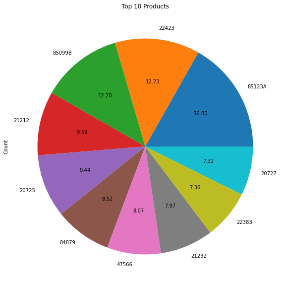

```python
pdf = pd.DataFrame(top_products[:10], columns=['Count'])

pdf.plot.pie(y='Count', autopct='%.2f', figsize=(10, 10), legend=False, title="Top 10 Products")
```

```python
bdf[bdf['StockCode'] == '85123A'].head(1)['Description']
```

```
102    WHITE HANGING HEART T-LIGHT HOLDER
Name: Description, dtype: object
```

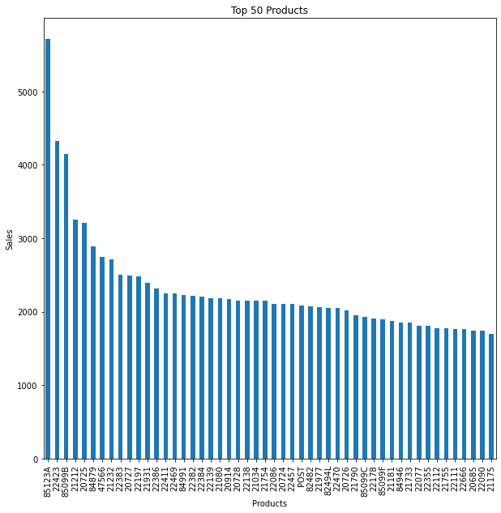

```python
pdf = pd.DataFrame(top_products[:50], columns=['Count'])
pdf['StockCode'] = pdf.index

pdf.plot.bar(y='Count', x='StockCode', figsize=(10, 10), title="Top 50 Products", xlabel="Products", ylabel='Sales', legend=False)
```

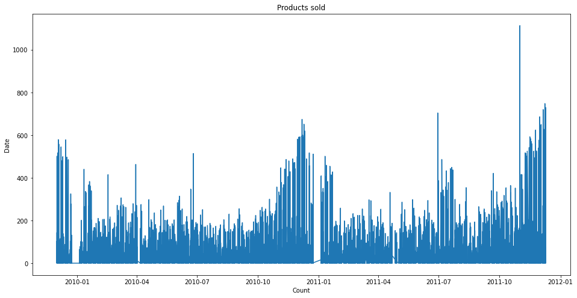

```python
plt.figure(figsize=(16, 8))
(bdf.InvoiceDate.value_counts().pipe((sns.lineplot, 'data')))
plt.title('Products sold')
plt.xlabel('Count')
plt.ylabel('Date')
```

When looking at sales numbers there seems to be an increase in products sold at the end of the year, and there seem to be a couple gaps. These gaps in data could either be missing data, or just periods that no products were sold.

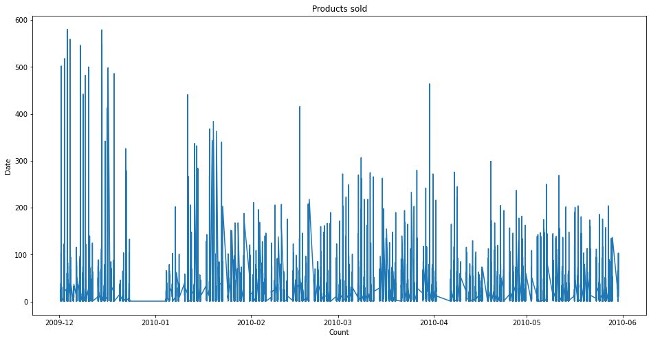

```python
plt.figure(figsize=(16, 8))
(bdf[bdf['InvoiceDate'] < '2010-06'].InvoiceDate.value_counts().pipe((sns.lineplot, 'data')))
plt.title('Products sold')
plt.xlabel('Count')
plt.ylabel('Date')
```

When zooming in on a smaller period, it is better visible how much the sales fluctuate, this is because the customers of this company are retailers who buy a lot at once infrequently, which would create spikes like the ones seen above.

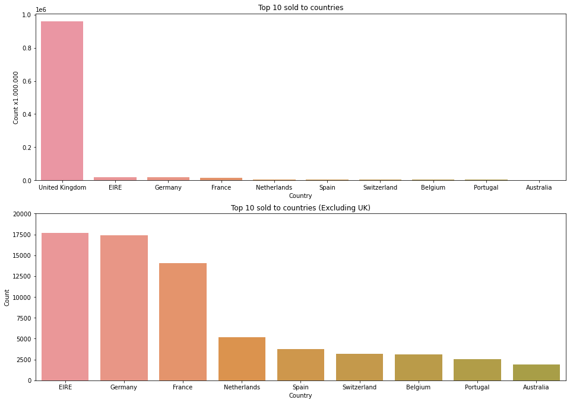

```python
fig, axes = plt.subplots(2, 1, figsize=(16,8))
plt.subplots_adjust(top=1.2)

cp = sns.countplot(ax=axes[0], x=bdf['Country'], order = bdf['Country'].value_counts().index)
cp.set(xlim=(None, 9.5), ylabel='Count x1.000.000', xlabel='Country', title='Top 10 sold to countries');

cp = sns.countplot(ax=axes[1], x=bdf['Country'], order = bdf['Country'].value_counts().index)
cp.set(xlim=(0.5, 9.5), ylim=(None, 20000), ylabel='Count', xlabel='Country', title='Top 10 sold to countries (Excluding UK)');
```

note: EIRE is Ireland

When looking at country sales, it is clear that almost all purchases are made within the UK, but that other countries do still purchase from the company. While the UK sales make up an overwhelming majority of the sales, I do think that there are overall enough sales done in individual countries for a recommendation system to make use of a customers location.

```python
np.average(bdf['Customer ID'].value_counts().values)
```

```
136.2438572871087
```

#### Conclusion

From exploring the data, it is seen that the data indeed shows great potential to be used for a customer recommendation system, from the identifiers for products and users given, to the amount of data points found per customer, country or product.

The data however does have to be perpared first, because the dataset is split into two semi-overlapping data sheets, these will have to be combined and made sure that all overlapping data is filtered properly, as to not leave duplicate entries.  
Furthermore, there are quite a few invoices made without a proper customerID, these transactions can't be tracked to any person, making it useless for the recommendation system and therefore have to be removed.  
Lastly, the dataset seems to not only contain automated sales data but also manually unstandardized inputs, these entries will cause problems such as illogical data (e.g. negative sales/quantity numbers) and outliers (e.g. large sales numbers, which should not cause too much issues), because the data contains what is expected to be refunded or returned products these sale entries should be dealt with properly as to not leave incorrect sales entries.

### Data Preparation

#### Merging Datasheets

A form of merging the data in a way that avoids the overlapping data was done during Data Understanding and will be used again here.

```python
import pandas as pd
import numpy as np
```

```python
df = pd.read_excel('Datasets/invoices.xlsx', sheet_name=[0,1])
```

```python
df_merge = df[1].merge(df[0].drop_duplicates(), on=df[0].columns.tolist(), how='left', indicator=True)
df = df[0].append(df_merge[df_merge['_merge'] == 'left_only'])
del df['_merge']
```

Setting the categorical data to be of a categorical Dtype

```python
df['Invoice'] = df['Invoice'].astype('category')
df['StockCode'] = df['StockCode'].astype('category')
df['Country'] = df['Country'].astype('category')
df.info()
```

```
<class 'pandas.core.frame.DataFrame'>
Int64Index: 1044848 entries, 0 to 541909
Data columns (total 8 columns):
 #   Column       Non-Null Count    Dtype
---  ------       --------------    -----
 0   Invoice      1044848 non-null  category
 1   StockCode    1044848 non-null  category
 2   Description  1040573 non-null  object
 3   Quantity     1044848 non-null  int64
 4   InvoiceDate  1044848 non-null  datetime64[ns]
 5   Price        1044848 non-null  float64
 6   Customer ID  809561 non-null   float64
 7   Country      1044848 non-null  category
dtypes: category(3), datetime64[ns](1), float64(2), int64(1), object(1)
memory usage: 57.4+ MB
```

Because of the merging of two dataframes, the indexing can get messed up and have multiple records on a single index, so the index will be reset to avoid this.

```python
df = df.reset_index()
```

Next will be removing the records with no customerID attached to them.

```python
df = df.dropna(subset=['Customer ID'])
```

```python
df.info()
```

```
<class 'pandas.core.frame.DataFrame'>
Int64Index: 809561 entries, 0 to 1044847
Data columns (total 9 columns):
 #   Column       Non-Null Count   Dtype
---  ------       --------------   -----
 0   index        809561 non-null  int64
 1   Invoice      809561 non-null  category
 2   StockCode    809561 non-null  category
 3   Description  809561 non-null  object
 4   Quantity     809561 non-null  int64
 5   InvoiceDate  809561 non-null  datetime64[ns]
 6   Price        809561 non-null  float64
 7   Customer ID  809561 non-null  float64
 8   Country      809561 non-null  category
dtypes: category(3), datetime64[ns](1), float64(2), int64(2), object(1)
memory usage: 51.2+ MB
```

All missing Customer ID columns have now been removed, this also seems to have gotten rid of all entries with a missing Description, indicating that this missing data might have had something to do with eachother, perhaps it were records filled in manually, thus missing some generaly critical information.

```python
df.describe()
```

|  | index | Quantity | Price | Customer ID |
| --- | --- | --- | --- | --- |
| count | 809561.000000 | 809561.000000 | 809561.000000 | 809561.000000 |
| mean | 276260.869944 | 12.460672 | 3.685980 | 15319.760422 |
| std | 147694.229739 | 190.301161 | 70.876558 | 1695.812057 |
| min | 0.000000 | -80995.000000 | 0.000000 | 12346.000000 |
| 25% | 150212.000000 | 2.000000 | 1.250000 | 13969.000000 |
| 50% | 280080.000000 | 5.000000 | 1.950000 | 15248.000000 |
| 75% | 402539.000000 | 12.000000 | 3.750000 | 16792.000000 |
| max | 541909.000000 | 80995.000000 | 38970.000000 | 18287.000000 |

```python
df.sort_values('Quantity').head(5)
```

|  | index | Invoice | StockCode | Description | Quantity | InvoiceDate | Price | Customer ID | Country |
| --- | --- | --- | --- | --- | --- | --- | --- | --- | --- |
| 1043360 | 540422 | C581484 | 23843 | PAPER CRAFT , LITTLE BIRDIE | -80995 | 2011-12-09 09:27:00 | 2.08 | 16446.0 | United Kingdom |
| 564562 | 61624 | C541433 | 23166 | MEDIUM CERAMIC TOP STORAGE JAR | -74215 | 2011-01-18 10:17:00 | 1.04 | 12346.0 | United Kingdom |
| 507225 | 507225 | C536757 | 84347 | ROTATING SILVER ANGELS T-LIGHT HLDR | -9360 | 2010-12-02 14:23:00 | 0.03 | 15838.0 | United Kingdom |
| 359669 | 359669 | C524235 | 21088 | SET/6 FRUIT SALAD PAPER CUPS | -7128 | 2010-09-28 11:02:00 | 0.08 | 14277.0 | France |
| 359670 | 359670 | C524235 | 21096 | SET/6 FRUIT SALAD PAPER PLATES | -7008 | 2010-09-28 11:02:00 | 0.13 | 14277.0 | France |

```python
df[(df['Customer ID'] == 16446) & (df['StockCode'] == 23843)]
```

|  | index | Invoice | StockCode | Description | Quantity | InvoiceDate | Price | Customer ID | Country |
| --- | --- | --- | --- | --- | --- | --- | --- | --- | --- |
| 1043359 | 540421 | 581483 | 23843 | PAPER CRAFT , LITTLE BIRDIE | 80995 | 2011-12-09 09:15:00 | 2.08 | 16446.0 | United Kingdom |
| 1043360 | 540422 | C581484 | 23843 | PAPER CRAFT , LITTLE BIRDIE | -80995 | 2011-12-09 09:27:00 | 2.08 | 16446.0 | United Kingdom |

Seen above the large inconsistent outliers such as large negative quantities seem to indeed be because of returns/refunds. This means that the customer did not want the product, and thus should be removed for our recommendation dataset (current the model would think the customer might want the product even more).

Thankfully the dataset has made this somewhat easier by having all refunds/negative quantity invoices start with a 'C'.

```python
refunds = df[df['Invoice'].astype('str').str.contains('C')]
print(f"Refund entries to remove: {len(refunds)}")
```

```
Refund entries to remove: 18446
```

Note this takes a while

```python
import os
def RemoveRefunds(refund, df):
#   Find refund in original df
    rowIndex = df[(df['Customer ID'] == refunds.loc[refund.name]['Customer ID']) &
     (df['StockCode'] == refunds.loc[refund.name]['StockCode']) &
     (df['Price'] == refunds.loc[refund.name]['Price']) &
     (df['Quantity'] == -refunds.loc[refund.name]['Quantity'])].head(1).index

#   Drop the found refund from original df
    df.drop(rowIndex, inplace=True)

#   Print to jupyter notebook
    os.write(1, bytes(f"({refund.name}) Removing Entry: {rowIndex}\n", encoding='utf-8'))

refunds.apply(axis=1, func=RemoveRefunds, df=df)
print('Done')
```

```
Done
```

Now all products that have been refunded are removed from the dataset, and the refund entries should be removed aswell.

```python
df = df[~df['Invoice'].astype('str').str.contains('C')]
```

```python
df.describe()
```

|  | index | Quantity | Price | Customer ID |
| --- | --- | --- | --- | --- |
| count | 784305.000000 | 784305.000000 | 784305.000000 | 784305.000000 |
| mean | 277041.105089 | 12.961602 | 3.031777 | 15329.131361 |
| std | 147699.577384 | 74.020673 | 11.300295 | 1694.868668 |
| min | 0.000000 | 1.000000 | 0.000000 | 12346.000000 |
| 25% | 151103.000000 | 2.000000 | 1.250000 | 13979.000000 |
| 50% | 281419.000000 | 5.000000 | 1.950000 | 15261.000000 |
| 75% | 403723.000000 | 12.000000 | 3.750000 | 16798.000000 |
| max | 541909.000000 | 19152.000000 | 4161.060000 | 18287.000000 |

```python
refunds.loc[471628]
```

```
index                                       471628
Invoice                                    C533814
StockCode                                    85047
Description    WHITE BEADED GARLAND STRING 20LIGHT
Quantity                                        -1
InvoiceDate                    2010-11-19 08:53:00
Price                                         5.55
Customer ID                                17714.0
Country                             United Kingdom
Name: 471628, dtype: object
```

```python
df[(df['Customer ID'] == 17714) & (df['StockCode'] == 85047)]
```

|  | index | Invoice | StockCode | Description | Quantity | InvoiceDate | Price | Customer ID | Country |
| --- | --- | --- | --- | --- | --- | --- | --- | --- | --- |
| 383513 | 383513 | 526238 | 85047 | WHITE BEADED GARLAND STRING 20LIGHT | 3 | 2010-10-11 08:30:00 | 6.35 | 17714.0 | United Kingdom |

While all found refunded products have been removed, some refund invoices do not have a perfectly matching purchase entry to be removed.  
For example, this instance above a customer bought 3 products and refunded 1, this indicates that the customer still kept some and might still be worth recommending to others (this could have occured because the customer bought 1 too many, or the product was damaged in shipping).

```python
df[df['StockCode'] == 'POST'].head(3)
```

|  | index | Invoice | StockCode | Description | Quantity | InvoiceDate | Price | Customer ID | Country |
| --- | --- | --- | --- | --- | --- | --- | --- | --- | --- |
| 89 | 89 | 489439 | POST | POSTAGE | 3 | 2009-12-01 09:28:00 | 18.0 | 12682.0 | France |
| 126 | 126 | 489444 | POST | POSTAGE | 1 | 2009-12-01 09:55:00 | 141.0 | 12636.0 | USA |
| 173 | 173 | 489447 | POST | POSTAGE | 1 | 2009-12-01 10:10:00 | 130.0 | 12362.0 | Belgium |

```python
df[df['StockCode'] == 'DOT'].head(3)
```

|  | index | Invoice | StockCode | Description | Quantity | InvoiceDate | Price | Customer ID | Country |
| --- | --- | --- | --- | --- | --- | --- | --- | --- | --- |
| 820445 | 317507 | 564764 | DOT | DOTCOM POSTAGE | 1 | 2011-08-30 10:49:00 | 11.17 | 14096.0 | United Kingdom |
| 826940 | 324002 | 565383 | DOT | DOTCOM POSTAGE | 1 | 2011-09-02 15:45:00 | 16.46 | 14096.0 | United Kingdom |
| 836694 | 333756 | 566217 | DOT | DOTCOM POSTAGE | 1 | 2011-09-09 15:17:00 | 13.16 | 14096.0 | United Kingdom |

There are also some records which are the postage price for the invoice, this is not a product and should not be recommended to users and should thus also be removed

```python
df = df[~(df['StockCode'] == 'POST')]
df = df[~(df['StockCode'] == 'DOT')]
df = df[~(df['StockCode'] == 'BANK CHARGES')]
```

Lastly there will be looked at the highest outliers for quantity and price.

```python
df[['Quantity', 'Price']].describe()
```

|  | Quantity | Price |
| --- | --- | --- |
| count | 782531.000000 | 782531.000000 |
| mean | 12.984396 | 2.966500 |
| std | 74.102901 | 10.315221 |
| min | 1.000000 | 0.000000 |
| 25% | 2.000000 | 1.250000 |
| 50% | 5.000000 | 1.950000 |
| 75% | 12.000000 | 3.750000 |
| max | 19152.000000 | 4161.060000 |

```python
df.sort_values('Quantity').tail()
```

|  | index | Invoice | StockCode | Description | Quantity | InvoiceDate | Price | Customer ID | Country |
| --- | --- | --- | --- | --- | --- | --- | --- | --- | --- |
| 1005060 | 502122 | 578841 | 84826 | ASSTD DESIGN 3D PAPER STICKERS | 12540 | 2011-11-25 15:57:00 | 0.0 | 13256.0 | United Kingdom |
| 127169 | 127169 | 501534 | 21085 | SET/6 WOODLAND PAPER CUPS | 12744 | 2010-03-17 13:09:00 | 0.1 | 13902.0 | Denmark |
| 127168 | 127168 | 501534 | 21091 | SET/6 WOODLAND PAPER PLATES | 12960 | 2010-03-17 13:09:00 | 0.1 | 13902.0 | Denmark |
| 127166 | 127166 | 501534 | 21099 | SET/6 STRAWBERRY PAPER CUPS | 12960 | 2010-03-17 13:09:00 | 0.1 | 13902.0 | Denmark |
| 90857 | 90857 | 497946 | 37410 | BLACK AND WHITE PAISLEY FLOWER MUG | 19152 | 2010-02-15 11:57:00 | 0.1 | 13902.0 | Denmark |

The large amount of quantity sales, seem to be valid as just large bulk purchases, seen as also the low price. It is also noticable that entry 1005060 as a price of 0, however this could just have been some kind of special deal.

```python
df.sort_values('Price').tail()
```

|  | index | Invoice | StockCode | Description | Quantity | InvoiceDate | Price | Customer ID | Country |
| --- | --- | --- | --- | --- | --- | --- | --- | --- | --- |
| 845935 | 342997 | 566927 | M | Manual | 1 | 2011-09-15 15:20:00 | 2033.10 | 17846.0 | United Kingdom |
| 800376 | 297438 | 562946 | M | Manual | 1 | 2011-08-11 09:38:00 | 2500.00 | 15581.0 | United Kingdom |
| 288706 | 288706 | 517483 | M | Manual | 1 | 2010-07-29 12:29:00 | 3610.50 | 12737.0 | France |
| 925315 | 422377 | 573080 | M | Manual | 1 | 2011-10-27 14:20:00 | 4161.06 | 12536.0 | France |
| 925312 | 422374 | 573077 | M | Manual | 1 | 2011-10-27 14:13:00 | 4161.06 | 12536.0 | France |

Some purchases seem to have been done manually, these seem to be one off large purchases with no proper product attached to them, and should thus also be removed.

```python
df = df[~(df['StockCode'] == 'M')]
```

```python
df.sort_values('Price').tail()
```

|  | index | Invoice | StockCode | Description | Quantity | InvoiceDate | Price | Customer ID | Country |
| --- | --- | --- | --- | --- | --- | --- | --- | --- | --- |
| 71038 | 71038 | 495755 | ADJUST | Adjustment by john on 26/01/2010 16 | 1 | 2010-01-26 16:29:00 | 342.80 | 14413.0 | United Kingdom |
| 249673 | 249673 | 513566 | ADJUST2 | Adjustment by Peter on Jun 25 2010 | 1 | 2010-06-25 14:15:00 | 358.47 | 17364.0 | United Kingdom |
| 71082 | 71082 | 495802 | ADJUST | Adjustment by john on 26/01/2010 17 | 1 | 2010-01-26 17:28:00 | 387.54 | 12748.0 | United Kingdom |
| 725620 | 222682 | 556446 | 22502 | PICNIC BASKET WICKER 60 PIECES | 1 | 2011-06-10 15:33:00 | 649.50 | 15098.0 | United Kingdom |
| 725609 | 222671 | 556444 | 22502 | PICNIC BASKET WICKER 60 PIECES | 60 | 2011-06-10 15:28:00 | 649.50 | 15098.0 | United Kingdom |

```python
df[df['StockCode'].astype('str').str.contains('ADJUST')]['StockCode'].unique()
```

```
['ADJUST', 'ADJUST2']
Categories (5305, object): [10002, 10080, 10109, 10120, ..., 'gift_0001_70', 'gift_0001_80', 'gift_0001_90', 'm']
```

```python
df[df['StockCode'].astype('str').str.contains('gift_0001_70')].head(3)
```

|  | index | Invoice | StockCode | Description | Quantity | InvoiceDate | Price | Customer ID | Country |
| --- | --- | --- | --- | --- | --- | --- | --- | --- | --- |

There also seem to be some none product price adjustments done manually which should be removed. When looking at the general unique printout above it is also seen that there are stockcode's for gift_0001_x0, these might have needed to be removed too, but they seem to have been part of the records containing no Customer ID and have all already been removed.

```python
df = df[~(df['StockCode'].astype('str').str.contains('ADJUST'))]
```

```python
df.sort_values('Price').tail()
```

|  | index | Invoice | StockCode | Description | Quantity | InvoiceDate | Price | Customer ID | Country |
| --- | --- | --- | --- | --- | --- | --- | --- | --- | --- |
| 554574 | 51636 | 540647 | 22655 | VINTAGE RED KITCHEN CABINET | 1 | 2011-01-10 14:57:00 | 295.0 | 17406.0 | United Kingdom |
| 292666 | 292666 | 517930 | 22655 | VINTAGE RED KITCHEN CABINET | 1 | 2010-08-03 10:38:00 | 295.0 | 15727.0 | United Kingdom |
| 621686 | 118748 | 546480 | 22656 | VINTAGE BLUE KITCHEN CABINET | 1 | 2011-03-14 11:38:00 | 295.0 | 13452.0 | United Kingdom |
| 725609 | 222671 | 556444 | 22502 | PICNIC BASKET WICKER 60 PIECES | 60 | 2011-06-10 15:28:00 | 649.5 | 15098.0 | United Kingdom |
| 725620 | 222682 | 556446 | 22502 | PICNIC BASKET WICKER 60 PIECES | 1 | 2011-06-10 15:33:00 | 649.5 | 15098.0 | United Kingdom |

```python
df.describe()
```

|  | index | Quantity | Price | Customer ID |
| --- | --- | --- | --- | --- |
| count | 781913.000000 | 781913.000000 | 781913.000000 | 781913.000000 |
| mean | 277044.164988 | 12.982574 | 2.923886 | 15334.848368 |
| std | 147702.187828 | 74.083294 | 4.213391 | 1691.931094 |
| min | 0.000000 | 1.000000 | 0.000000 | 12346.000000 |
| 25% | 151112.000000 | 2.000000 | 1.250000 | 13985.000000 |
| 50% | 281426.000000 | 5.000000 | 1.950000 | 15271.000000 |
| 75% | 403730.000000 | 12.000000 | 3.750000 | 16800.000000 |
| max | 541908.000000 | 19152.000000 | 649.500000 | 18287.000000 |

All outliers seem to have been dealt with now.

Now that the data is fully cleaned, it will be saved back into a csv file for easier access during future phases.

```python
df.to_csv("Datasets/invoices_prepared.csv", sep="|")
```

#### Model Data Preperation

Because most recommender models have specific data requirements, I will be having to convert the data stored into a structure that can be used fore modelling.  
The most important part for this is that most modelling libraries require a form of rating score to train the model on, this will allow for easier evaluation as the real rating can be compared to a predicted rating the model creates.  
The data used however, does not contain any form of ratings value, for this I will instead be using the quantity of products sold, this is a quantifiable feature to show how much a person likes the product.  
sale quantities however vary a lot within the data, because of this I will be excluding the largest outliers and Min/Max scaling the data so that it will conform to a good 1/10 rating scale.

```python
import pandas as pd
import numpy as np

cols=['Invoice', 'StockCode', 'Description', 'Quantity', 'InvoiceDate', 'Price', 'Customer ID', 'Country']
dtypes={
    'Invoice' : 'category',
    'StockCode' : 'category',
    'Description' : 'str',
    'Quantity' : 'float64',
    'Price' : 'float64',
    'Customer ID' : 'category',
    'Country' : 'category'
}
df = pd.read_csv("Datasets/invoices_prepared.csv", sep="|", parse_dates=['InvoiceDate'], usecols=cols, dtype=dtypes)
df.info()
```

```
<class 'pandas.core.frame.DataFrame'>
RangeIndex: 781884 entries, 0 to 781883
Data columns (total 8 columns):
 #   Column       Non-Null Count   Dtype
---  ------       --------------   -----
 0   Invoice      781884 non-null  category
 1   StockCode    781884 non-null  category
 2   Description  781884 non-null  object
 3   Quantity     781884 non-null  float64
 4   InvoiceDate  781884 non-null  datetime64[ns]
 5   Price        781884 non-null  float64
 6   Customer ID  781884 non-null  category
 7   Country      781884 non-null  category
dtypes: category(4), datetime64[ns](1), float64(2), object(1)
memory usage: 32.2+ MB
```

Because of the way most recommender libraries work, they require a rating score from users to find products that customers want, my dataset however does not have this feature. However, I can create a version of a rating feature by using the quantity of purchased items by the user.

Create a dataframe that has a record for each instance of an item being bought by a unique user.

```python
rdf = pd.DataFrame(columns=['User', 'Item', 'Rating'])

for product in df['StockCode'].unique():
    rdf = rdf.append(pd.DataFrame({'User':df[df['StockCode'] == product]['Customer ID'].unique(), 'Item':product, 'Rating':0}))
```

Fill the rating column of each unique purchase with the quantity sold in total

```python
rdf['Rating'] = rdf.apply(axis=1, func=lambda x: df[(df['StockCode'] == x.Item) & (df['Customer ID'] == x.User)]['Quantity'].sum())
```

```python
rdf.to_csv("Datasets/model_data.csv", sep="|")
```

To make sure the scaling does not reduce the amount of perceived detail by squashing most numbers because of a couple outliers, I will be removing the outliers.

```python
srdf = rdf.copy()
srdf = srdf[srdf['Rating'] <= (rdf['Rating'].mean() + rdf['Rating'].std())]
```

Min/Max scaling the data will return values between a scale of 0-1, to give the model a better readability I will multiply the value by 10 to create a 0-10 scale.

```python
from sklearn.preprocessing import MinMaxScaler

scaler = MinMaxScaler()
srdf[['Rating']] = pd.DataFrame(scaler.fit_transform(srdf[['Rating']]), columns=['Rating'])
srdf[['Rating']] = srdf[['Rating']]*10
```

```python
srdf.to_csv("Datasets/model_data_scaled.csv", sep="|")
```

## Predictions

### Preprocessing

For this challenge I will be trying to train an unsupervised recommender model, this model will be recommending products to customers based on collaborative filtering.

#### Model Selection

As said above, I will be trying to implement a form of unsupervised clustering recommender model, During the Sub Questions I looked into the different implementations of a model like this. From the research done I found two commonly used models, a user and a product based recommendation system.  
As to be expected from the names, user based recommendation systems make use of finding users with similar purchase histories and recommends products that under set group has been purchased, while product based will recommend products similar to the ones bought previously.

The dataset used during this challenge is heavily focussed on user purchases, this means that the dataset has very little information on features for the products themselves. On the other hand, my dataset does contain on average a large amount of purchases per user, this will be able to create a good profile to group the users with.

Because of the lack of detailed product information, I will be attempting to do a form of user based/collaborative filtering for my recommendation system.

For the implementation of the model, I will be using a library called [scikit-surprise](http://surpriselib.com/), this library is specifically made for recommender systems.

#### Feature Selection

Because recommendation systems are unsupervised, there is little in feature selection that will be done manually, user based recommendation systems, do not need a lot of different features to use. The model will base it's recommendations on the purchase history of the user and similar user like him, this means that the data will have to contain an identifier for users and the products purchased.  
For this challenge I will be using the features:

- Customer ID
- StockCode
- Ratings

The Customer ID will be used to identify the user, while the StockCode will be used to know what product the user has bought, I will also add Ratings as an extra feature to give a better indication of how popular a product is, and thus how aggresive it should be recommended, this will also give a good metric to use for evaluation.

### Modelling

The model library requires a special format of data, a pandas dataframe will have to be converted to this format which has been done in the steps below.

```python
import pandas as pd
import numpy as np

srdf = pd.read_csv("Datasets/model_data_scaled.csv", sep="|", usecols=['User', 'Item', 'Rating'])
# Index is not loaded properly causing duplicate indexes to exist
srdf = srdf.reset_index(drop=True)
```

Creating a recommendation system starts by using algorithms that will help the system, these algorithms can be collaborative filtering algorithms or other techniques such as Matrix Factorization.

I will be working towards implementing a collaborative filtering implementation, but first will try a more basic algorithm called NormalPredictor in scikit surprise, this will create a baseline to improve upon. I will be doing all my modelling using cross_validation as to allow for good evaluation and get rid of possible data split biases.

```python
from surprise.reader import Reader
from surprise import NormalPredictor
from surprise import Dataset
from surprise.model_selection import cross_validate

# Create reader to parse pandas data
reader = Reader(line_format='user item rating', rating_scale=(0, srdf['Rating'].max()))
# Read pandas data into surprise dataformat
data = Dataset.load_from_df(srdf, reader)

# We'll use the famous SVD algorithm.
npr = NormalPredictor()

# Run 5-fold cross-validation and print results
cross_validate(npr, data, measures=['RMSE', 'MAE'], cv=5, verbose=True)
```

```
Evaluating RMSE, MAE of algorithm NormalPredictor on 5 split(s).

                  Fold 1  Fold 2  Fold 3  Fold 4  Fold 5  Mean    Std
RMSE (testset)    1.0783  1.0835  1.0987  1.0827  1.0816  1.0850  0.0071
MAE (testset)     0.6991  0.7005  0.7061  0.7006  0.7032  0.7019  0.0025
Fit time          0.49    0.62    0.67    0.63    0.63    0.61    0.06
Test time         0.44    0.43    0.44    0.44    1.17    0.59    0.29
```

```
{'test_rmse': array([1.0782873 , 1.08353043, 1.09872329, 1.08270499, 1.08164345]),
 'test_mae': array([0.69908444, 0.70052087, 0.70609757, 0.70060022, 0.70323309]),
 'fit_time': (0.49271464347839355,
  0.6183121204376221,
  0.6671798229217529,
  0.6312768459320068,
  0.6312780380249023),
 'test_time': (0.44381070137023926,
  0.4328789710998535,
  0.44082117080688477,
  0.44081950187683105,
  1.1728949546813965)}
```

As seen from the results above, this model is already pretty good in predicting the Ratings score (which in reality is an identifier for the quantity the user will buy), it gets within an error of 1 with the prediction on a scale from 0-10, I would say that this is already fairly good, when it comes to finding the products that the customer is most likely to buy in large amounts.

Next I will be finding the predictions the algorithm will make for a signle user, this way I can get an actually feel of how the model works in the real world.

```python
trainSet = data.build_full_trainset()

anti_testset_user = []
targetUser = 0 #inner_id of the target user
fillValue = trainSet.global_mean
user_item_ratings = trainSet.ur[targetUser]
user_items = [item for (item,_) in (user_item_ratings)]
user_items
ratings = trainSet.all_ratings()
for iid in trainSet.all_items():
    if(iid not in user_items):
        anti_testset_user.append((trainSet.to_raw_uid(targetUser),trainSet.to_raw_iid(iid),fillValue))

predictions = np.test(anti_testset_user)
```

```python
predictions[0]
```

[output not shown]

```python
pred = pd.DataFrame(predictions)
pred = pred.sort_values(by=['est'], ascending = False)
pred.head(10)['iid'].to_list()
```

[output not shown]

Above I have highlighted the top 10 products that the model predicts the target user will buy the most of, with the highest one being a White/pink chick decoration.

Next I will be attempting to use a nearest neighbour implementation, this can either use product or user based filtering, so I will be using user based (this is a form of collaborative filtering).

```python
from surprise import KNNBasic

sim_options = {'name': 'cosine',
               'user_based': True
               }

knn = KNNBasic(sim_options=sim_options)

cross_validate(knn, data, measures=['RMSE', 'MAE'], cv=5, verbose=True)
# Error probably occurs because of division by zero
```

```
Computing the cosine similarity matrix...
```

```
Done computing similarity matrix.
Computing the cosine similarity matrix...
Done computing similarity matrix.
Computing the cosine similarity matrix...
Done computing similarity matrix.
Computing the cosine similarity matrix...
Done computing similarity matrix.
Computing the cosine similarity matrix...
Done computing similarity matrix.
Evaluating RMSE, MAE of algorithm KNNBasic on 5 split(s).

                  Fold 1  Fold 2  Fold 3  Fold 4  Fold 5  Mean    Std
RMSE (testset)    0.8522  0.8573  0.8697  0.8489  0.8593  0.8575  0.0071
MAE (testset)     0.4729  0.4749  0.4774  0.4718  0.4743  0.4743  0.0019
Fit time          19.87   20.12   20.89   19.33   18.81   19.80   0.70
Test time         15.77   16.14   16.81   15.94   15.70   16.07   0.40
```

```
{'test_rmse': array([0.85224029, 0.85732596, 0.86974703, 0.84885421, 0.85926797]),
 'test_mae': array([0.47290455, 0.47487359, 0.47744048, 0.47182796, 0.47433067]),
 'fit_time': (19.868562936782837,
  20.118053436279297,
  20.887202978134155,
  19.334280729293823,
  18.810492038726807),
 'test_time': (15.772833347320557,
  16.13930869102478,
  16.811049699783325,
  15.936309576034546,
  15.699994564056396)}
```

The KNN model does indeed perform better than the normalpredictor, this makes sense since the normalpredictor more or less randomly predicts a value and then tries to assume the correct value by the dataset's other datapoints. KNN on the other hand actually makes use of similar users to crowd source a good prediction.

An MAE of below 0.5 with a very small std shows that the model is very good at predicting what a customer will buy and how much of it with a high amount of certainty.

```python
predictions = knn.test(anti_testset_user)
pred = pd.DataFrame(predictions)
pred.sort_values(by=['est'],inplace=True,ascending = False)
pred.head(10)['iid'].to_list()
```

```
['21212',
 '22086',
 '85099B',
 '84879',
 '21080',
 '22555',
 '21977',
 '82494L',
 '84991',
 '21121']
```

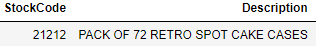

Above I have once again created a recommendation of products for the same target user as before, as seen it is recommending other products, this time a 72 pack of retro spot cake cases.

#### Model Tuning

Next I will be trying to find the best hyper parameters to use on the knn model, this will increase the performance of the model and hopefully give even better recommendations to users.

The two hyper parameters to tune for knn are k and min_k, where k is the amount of neighbours to consider and min_k being the minimum amount of neighbours to use.

```python
from surprise.model_selection import GridSearchCV

# k: 40 default
# min_k: 1 default
param_grid = {'k': [20,40,60],
              'min_k': [1,5,20],}

grid_search = GridSearchCV(KNNBasic, param_grid, measures=['rmse','mae'], cv=3)
grid_search.fit(data)
```

[output not shown]

Below are a couple different readouts of the evaluation metrics from the grid search done.

```python
print(grid_search.best_score['rmse'])
print(grid_search.best_score['mae'])
print(grid_search.best_params['rmse'])
```

```
0.8520493338906449
0.46669816641546297
{'k': 60, 'min_k': 5}
```

```python
results = pd.DataFrame.from_dict(grid_search.cv_results)
```

```python
results.sort_values('rank_test_rmse', ascending=True).head(6)
```

|  | split0_test_rmse | split1_test_rmse | split2_test_rmse | mean_test_rmse | std_test_rmse | rank_test_rmse | split0_test_mae | split1_test_mae | split2_test_mae | mean_test_mae | std_test_mae | rank_test_mae | mean_fit_time | std_fit_time | mean_test_time | std_test_time | params | param_k | param_min_k |
| --- | --- | --- | --- | --- | --- | --- | --- | --- | --- | --- | --- | --- | --- | --- | --- | --- | --- | --- | --- |
| 7 | 0.848691 | 0.858797 | 0.848659 | 0.852049 | 0.004772 | 1 | 0.466442 | 0.467891 | 0.465761 | 0.466698 | 0.000888 | 1 | 5.098562 | 0.234056 | 28.376765 | 2.349399 | {'k': 60, 'min_k': 5} | 60 | 5 |
| 6 | 0.848813 | 0.858923 | 0.848787 | 0.852174 | 0.004772 | 2 | 0.466599 | 0.468042 | 0.465905 | 0.466848 | 0.000890 | 2 | 4.825441 | 0.008159 | 24.803616 | 0.161551 | {'k': 60, 'min_k': 1} | 60 | 1 |
| 8 | 0.848927 | 0.859112 | 0.848903 | 0.852314 | 0.004807 | 3 | 0.467359 | 0.468995 | 0.466686 | 0.467680 | 0.000970 | 3 | 4.890807 | 0.018970 | 25.483878 | 0.207982 | {'k': 60, 'min_k': 20} | 60 | 20 |
| 4 | 0.852030 | 0.861966 | 0.851897 | 0.855298 | 0.004716 | 4 | 0.469446 | 0.470905 | 0.468511 | 0.469621 | 0.000985 | 4 | 5.222245 | 0.278803 | 28.732002 | 4.907374 | {'k': 40, 'min_k': 5} | 40 | 5 |
| 3 | 0.852151 | 0.862091 | 0.852025 | 0.855422 | 0.004716 | 5 | 0.469603 | 0.471055 | 0.468655 | 0.469771 | 0.000987 | 5 | 4.840373 | 0.027351 | 22.424946 | 0.053147 | {'k': 40, 'min_k': 1} | 40 | 1 |
| 5 | 0.852264 | 0.862280 | 0.852140 | 0.855562 | 0.004751 | 6 | 0.470363 | 0.472009 | 0.469436 | 0.470603 | 0.001064 | 6 | 5.130217 | 0.401590 | 23.135042 | 0.680291 | {'k': 40, 'min_k': 20} | 40 | 20 |

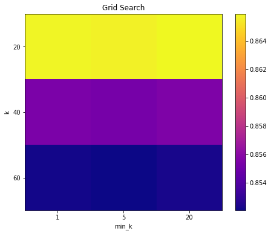

```python
scores = grid_search.cv_results['mean_test_rmse'].reshape(3,3)
scores

plt.figure(figsize=(8, 6))
plt.imshow(scores, interpolation='nearest', cmap=plt.cm.plasma)
plt.grid(False)
plt.xlabel('min_k')
plt.ylabel('k')
plt.colorbar()
plt.xticks(np.arange(3), [1, 5, 20])
plt.yticks(np.arange(3), [20, 40, 60])
plt.title('Grid Search')
plt.show()
```

From the data above, it is visible that the best hyperparemeter order is k:60 & min_k:5 this has the lowest Root Mean Square Error (RMSE), this means that any change in the RMSE has an exponential affect on the results unlike MAE which is linear.

It is also visible from the heatmap, that while the higher k the 'better' the model, the best min_k is actually 5, which was the middle option for the gridsearch.  
Not all customers might have a high amount of neighbours to use for recommendations, for this reason I think that the slightly lower performance is worth more than having the chance to overfit the model by going with a high k value.

### Evaluation

For this challenge I wanted to create a recommendation system, in the same vein as how youtube or amazon might recommend you content/products. For this I have done extensive research into how this is achieved in the real world.  
During this research I found multiple different methods of creating a recommendation system, for this I ended up choosing an unsupervised collaborative filtering model, the models used were all supplied by the scikit surprise library.

Getting e-commerce data was sadly not as easy as I had hoped, seen as companies and governments rather keep this private, however I did find a dataset for this on the UCI repositories, this dataset contained a lot of sales records for an e-commerce whole saler based in the UK. The dataset supplied me with sales of products and the user it was sold to. It was noticeable that there were a lot of cleaning steps that went into actually preparing the data, this is however to be expected from real world companies who do not have time to setup or maintain a perfectly automated system.

Because of the data used, I ran into problems finding viable models to use, seen as unsupervised models are more like a blackbox, where no one really knows what the model is doing, it becomes hard to evaluate a model's performance. For this reason a lot of models decide to use a ratings value to use for classifying the best products to recommend and as an evaluation metric of how the model performs.  
Sadly, my data does not contain a ratings metric, what the dataset did contain was a quantity measure of how much a user bought of a product. Seen as the customers of this whole saler are mostly small stores who resell the products, having a user buy more of a product would be a good equivelant for a ratings measure.  
I ended up using a scaled quantity measure as a 1-10 rating score.

While it is not possible to quantify the actual new products a user has been recommended without directly working with the e-commerce company who supplied the data, it is very interesting to see which products are being recommended.

# Delivery

### Collecting

While the viability of a recommendation system in the real world has already been looked into during the Sub Questions, the viability of this system within the specific domain this project functions (this being the e-commerce company supplying the data) will have to be first further evaluated.

As mentioned during the Evaluation, because I do not have direct contact with the e-commerce company I obtained the data from, I am not able to test out my model in a real world scenario.  
Not being able to test out the model in the real world, greatly limits my ability to gather feedback on the performance of the model, seen as the model is unsupervised and thus functions more like a blackbox.

To get around this to a certain degree; Recommendation models require a scoring system to use as a form of evaluation, the model will try to predict how a user will score certain products, this can in change be compared to the real world score the user gave, as to give an estimate of how good the model is at predicting what products certain users will enjoy.  
From this scoring test it was found that the model used was very accurate in it's assumptions, it was able to predict the a user's given score within a 0.5 error (with the scores ranging from 0-10).

The low error range of the model found using the score evaluation shows that the model is at least capable of prediction it's user's behaviors to a certain degree. Furthermore, the model uses a form of nearest neighbour to recommend new products, meaning users with similar product interests will be recommended products that among that group are often bought, the model had no problem with this, no matter how large the groups had to be while model tuning, showing that the users in the dataset indeed can be grouped into similarity groups, proving the viability of a collaborative filtering system.

### Documenting

The documenting phase goes over the process of this project, my personal findings/reasoning and the applications of the project.  
The document for this can be found [online](https://github.com/Thomas-Molen/FHICT-S4-AI/blob/main/OpenProgram/Documentation.pdf), or if possible locally.

### Reporting

The Delivery Report will be a visual report as one that would be shown to a stakeholder, this will go over the project's results, possible impact and future possibilities.  
Just like Documentation, this delivery report can be found [online](https://github.com/Thomas-Molen/FHICT-S4-AI/blob/main/OpenProgram/Delivery%20Report.pdf) or if possible locally.